# Data visualization tools

# Overview

The `supermarket` data are synthetic but realistic observations of customer interactions in various counties. The exercises in this document are based on a [tutorial](https://uc-r.github.io/cleveland-dot-plots) written on the UC Business Analytics blog

## Import

```r
# set global rmarkdown options
# echo = TRUE     --> show code blocks in markdown doc
# message = FALSE --> suppress package startup and other messages
knitr::opts_chunk$set(echo = TRUE, message = FALSE)

# Load packages
library(tidyverse)  # includes dplyr - filter / select
library(gt)
library(readxl)
library(janitor)


supermarket <- read_excel(
  # the file location
  path = "data/Supermarket Transactions.xlsx",
  # the sheet name to pull data from
  # you can also use numeric order of sheets
  sheet = "Data"
)
```

## Data dictionary

Review this briefly and use it as a reference to engage with the exercises below.

```r
supermarket_descr <-
  c(
    "Transaction"        = "transaction number",
    "Purchase Date"      = "date of purchase",
    "Customer ID"        = "customer identification",
    "Gender"             = "--",
    "Marital Status"     = "--",
    "Homeowner"          = "--",
    "Children"           = "number of kids at home",
    "Annual Income"      = "income of customer",
    "City"               = "--",
    "State or Province"  = "--",
    "Country"            = "Canada, Mexico, or USA",
    "Product Family"     = "drink, food, or non-consumable",
    "Product Department" = "the item's department",
    "Product Category"   = "the item's type",
    "Units Sold"         = "number of items sold",
    "Revenue"            = "money generated by the transaction"
  )

# the enframe function transforms a vector into a tibble,
enframe(supermarket_descr) %>%
  gt(rowname_col = "name") %>%
  tab_stubhead(label = 'Variable name') %>%
  cols_label(value = 'Variable description') %>%
  cols_align('right') %>%
  tab_header(title = 'Description of Super Market data')
```

Description of Super Market data

| Variable name | Variable description |
| --- | --- |
| Transaction | transaction number |
| Purchase Date | date of purchase |
| Customer ID | customer identification |
| Gender | -- |
| Marital Status | -- |
| Homeowner | -- |
| Children | number of kids at home |
| Annual Income | income of customer |
| City | -- |
| State or Province | -- |
| Country | Canada, Mexico, or USA |
| Product Family | drink, food, or non-consumable |
| Product Department | the item's department |
| Product Category | the item's type |
| Units Sold | number of items sold |
| Revenue | money generated by the transaction |

# Pre-requisites

Before starting these exercises, you should have a good understanding of

1. The [Derive Information with dplyr](https://rstudio.cloud/learn/primers/2.3) Primer.
2. Chapter 5 of [R for Data Science](https://r4ds.had.co.nz/transform.html)

# Exercise 1

Use the `janitor` package to clean your dataset’s names. Then,

- group your data by city and gender,
- compute the sum of revenue for each group

In the summarized data,

- (hint: `fct_recode`) convert gender to a factor with categories
  - ‘Male customers’
  - ‘Female customers’
- (hint: `fct_reorder`) convert `city` to a factor with levels ordered by revenue.
- Don’t forget to `ungroup` your data after summarizing!

```r
# your code goes here
```

Your solution should look like this:

```r
read_rds('solutions/01_solution.rds')
```

| city | gender | revenue |
| --- | --- | --- |
| Acapulco | Female customers | 2565.51 |
| Acapulco | Male customers | 2595.80 |
| Bellingham | Female customers | 453.36 |
| Bellingham | Male customers | 539.27 |
| Beverly Hills | Female customers | 5050.46 |
| Beverly Hills | Male customers | 5269.71 |
| Bremerton | Female customers | 5269.89 |
| Bremerton | Male customers | 5705.00 |
| Camacho | Female customers | 3643.30 |
| Camacho | Male customers | 2154.15 |

[output cut: 36 more lines]

# Exercise 2

Using the summarized data from exercise 1, re-create the figure presented during lecture:

```r
# Your code goes here
```

Your solution should look like this:

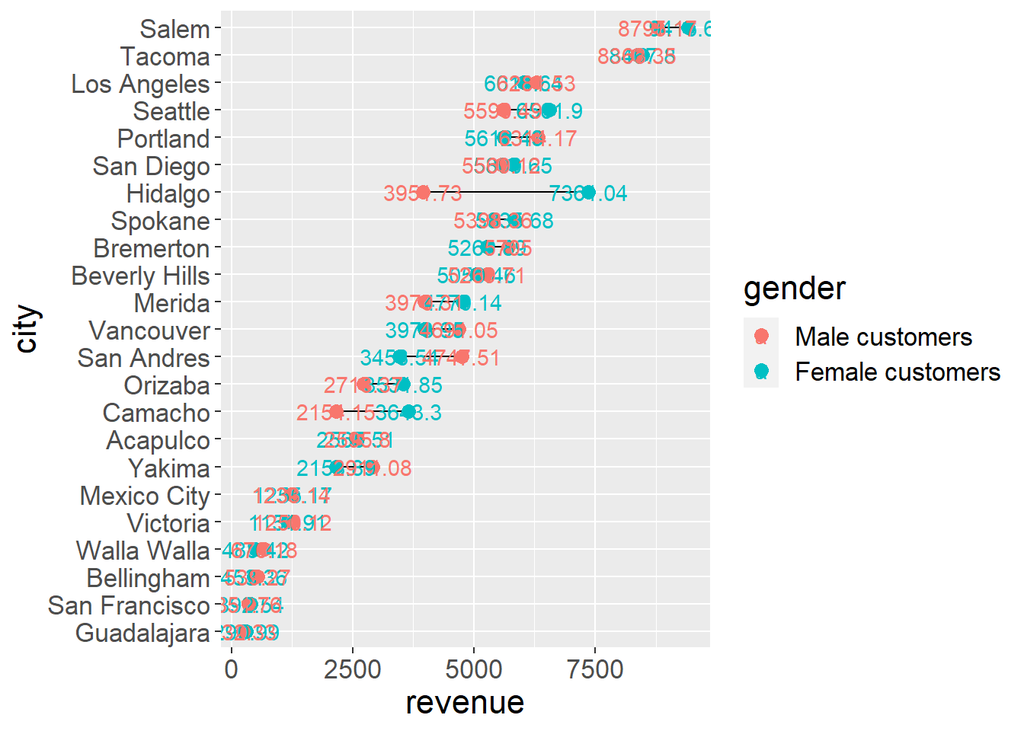

```r
read_rds('solutions/02_solution.rds')
```

# Exercise 3

create two datasets: `left_label` and `right_label`:

- `left_label` should contain the rows of your summarized data from exercise 1 that are on the left hand side of the plot from exercise 2.
- `right_label` should contain the rows of your summarized data from exercise 1 that are on the right hand side of the plot from exercise 2.

```r
# Your code goes here
```

Your solution should look like this:

```r
read_rds('solutions/03_solution.rds')
```

```
## $left_label
## # A tibble: 23 x 3
## # Groups:   city [23]
##    city          gender           revenue
##    <fct>         <fct>              <dbl>
##  1 Guadalajara   Male customers      232.
##  2 San Francisco Male customers      352.
##  3 Bellingham    Female customers    453.
##  4 Walla Walla   Female customers    488.
##  5 Victoria      Female customers   1152.
##  6 Mexico City   Male customers     1233.
##  7 Yakima        Female customers   2159.
##  8 Acapulco      Female customers   2566.
##  9 Camacho       Male customers     2154.
## 10 Orizaba       Male customers     2713.
## # ... with 13 more rows
##
## $right_label
## # A tibble: 23 x 3
## # Groups:   city [23]
##    city          gender           revenue
##    <fct>         <fct>              <dbl>
##  1 Guadalajara   Female customers    291.
##  2 San Francisco Female customers    393.
##  3 Bellingham    Male customers      539.
##  4 Walla Walla   Male customers      676.
##  5 Victoria      Male customers     1250.
##  6 Mexico City   Female customers   1255.
##  7 Yakima        Male customers     2911.
##  8 Acapulco      Male customers     2596.
##  9 Camacho       Female customers   3643.
## 10 Orizaba       Female customers   3532.
## # ... with 13 more rows
```

# Exercise 4

```r
# Your code goes here
```

Your solution should look like this:

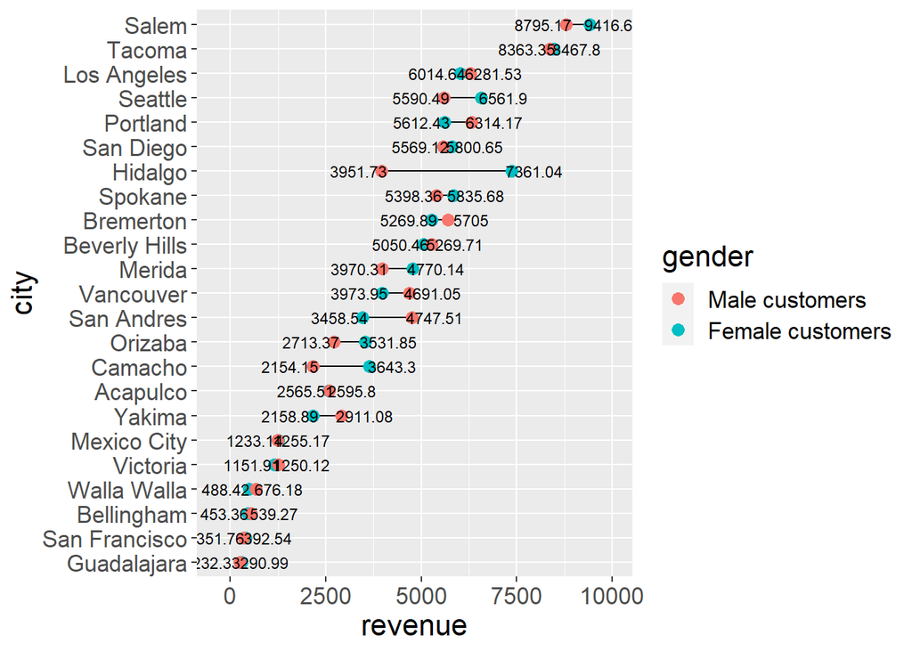

```r
read_rds('solutions/04_solution.rds')
```

# Exercise 5

- Create a dataset called `big_diff` that shows the absolute value of the difference in revenue generated between male customers and female customers in each city.
- Filter this dataset so that only cities with difference greater than $750 are retained.
- Filter the `right_label` data from exercise 3 to retain only the rows where `city` is in `big_diff$city` values.
- Create a dataset called `highlight` that filters your summarized data from exercise 1 to retain only the rows where `city` is in `dig_diff$city`

```r
# Your code goes here
```

Your filtered `right_label` and `highlight` datasets should look like this:

```r
read_rds('solutions/05_solution.rds')
```

```
## $right_label
## # A tibble: 7 x 4
##   city       gender           revenue diff
##   <fct>      <fct>              <dbl> <chr>
## 1 Yakima     Male customers     2911. + $752
## 2 Camacho    Female customers   3643. + $1489
## 3 Orizaba    Female customers   3532. + $818
## 4 San Andres Male customers     4748. + $1289
## 5 Merida     Female customers   4770. + $800
## 6 Hidalgo    Female customers   7361. + $3409
## 7 Seattle    Female customers   6562. + $971
##
## $highlight
## # A tibble: 14 x 3
##    city       gender           revenue
##    <fct>      <fct>              <dbl>
##  1 Camacho    Female customers   3643.
##  2 Camacho    Male customers     2154.
##  3 Hidalgo    Female customers   7361.
##  4 Hidalgo    Male customers     3952.
##  5 Merida     Female customers   4770.
##  6 Merida     Male customers     3970.
##  7 Orizaba    Female customers   3532.
##  8 Orizaba    Male customers     2713.
##  9 San Andres Female customers   3459.
## 10 San Andres Male customers     4748.
## 11 Seattle    Female customers   6562.
## 12 Seattle    Male customers     5590.
## 13 Yakima     Female customers   2159.
## 14 Yakima     Male customers     2911.
```

# Exercise 6

Create a plot similar to that from exercise 4, but this time

- make lines and points have `alpha` of 1/2.
- color the lines `'grey'`
- use only the `right_label` data to add text to the plot
- Set `label` to be the difference in revenue rather than revenue.

```r
# Your code goes here
```

Your solution should look like this:

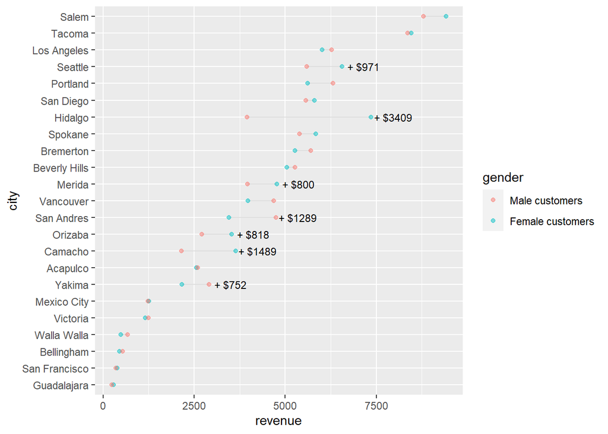

```r
read_rds('solutions/06_solution.rds')
```

# Exercise 7

- Add lines and points to the figure you created in exercise 6, using the `highlight` data you created in exercise 5.
- Use `scale_x_continuous`, setting `labels` to `scales::dollar` so that your x-axis will show dollar signs.
- Modify your x-axis and y-axis labels.

```r
# Your code goes here
```

Your solution should look like this:

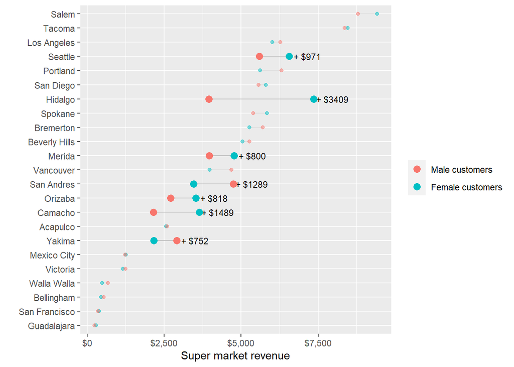

```r
read_rds('solutions/07_solution.rds')
```

# Exercise 8

Apply color palettes, theme elements, and legend manipulations to make your figure clear and concise.

```r
# Your code goes here
```

Your solution should look like this:

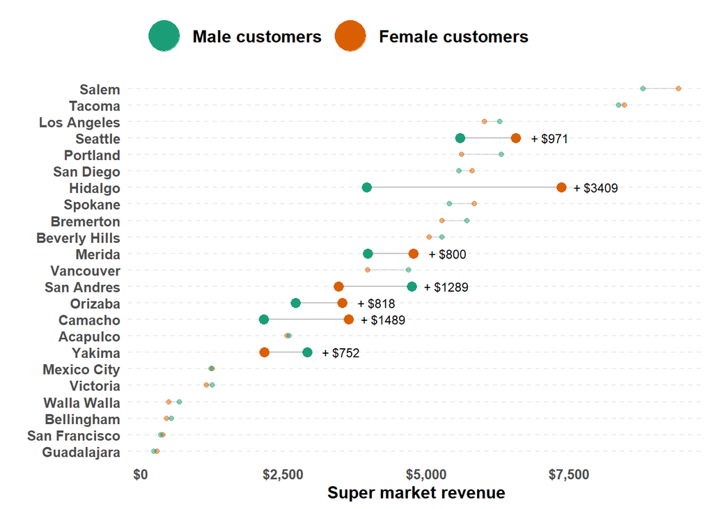

```r
read_rds('solutions/08_solution.rds')
```